# Statistics 533: Final Project - Survival Analysis for Malignant Melanoma

Yitao Guan,Seoungyeon Shim, Duc Truong, Meraj Khandakar,Jingxuan Zhang

## Data Structured and Components

#### time

Survival time in days since the operation, possibly censored.

#### status

The patients status at the end of the study. 1 indicates that they had died from melanoma, 2 indicates that they were still alive and 3 indicates that they had died from causes unrelated to their melanoma.

#### sex

The patients sex; 1=male, 0=female.

#### age

Age in years at the time of the operation.

#### year

Year of operation.

#### thickness

Tumour thickness in mm.

#### ulcer

Indicator of ulceration; 1=present, 0=absent."

[video not shown]

Sumary of statistics for our components.

```
## $Continuous
##               label var_type   n missing_n missing_percent   mean     sd    min
## X                 X    <int> 205         0             0.0  103.0   59.3    1.0
## time           time    <int> 205         0             0.0 2152.8 1122.1   10.0
## status       status    <int> 205         0             0.0    1.8    0.6    1.0
## sex             sex    <int> 205         0             0.0    0.4    0.5    0.0
## age             age    <int> 205         0             0.0   52.5   16.7    4.0
## year           year    <int> 205         0             0.0 1969.9    2.6 1962.0
## thickness thickness    <dbl> 205         0             0.0    2.9    3.0    0.1
## ulcer         ulcer    <int> 205         0             0.0    0.4    0.5    0.0
##           quartile_25 median quartile_75    max
## X                52.0  103.0       154.0  205.0
## time           1525.0 2005.0      3042.0 5565.0
## status            1.0    2.0         2.0    3.0
## sex               0.0    0.0         1.0    1.0
## age              42.0   54.0        65.0   95.0
## year           1968.0 1970.0      1972.0 1977.0
## thickness         1.0    1.9         3.6   17.4
## ulcer             0.0    0.0         1.0    1.0
##
## $Categorical
## data frame with 0 columns and 205 rows
```

Constructing our data frame. We define 3 groups of classification for failure time: - General mortality where 2 is alive, and 1/3 are death. - MM mortality comparing with 1 die by MM, 2/3 are alive. - Censoring adjust for competing risks 2 is alive, 1 is death by MM adjusting for 3.

```r
melanoma.df = melanoma %>%mutate(

    # general mortality where 2 is alive, and  1/3 are death
    status_general = ifelse(melanoma$status == 2, 0, 1),

    # MM mortality comparing with 1 die by MM, 2/3 are alive
    status_mm = case_when(melanoma$status==3 ~  0, melanoma$status==2 ~ 0,melanoma$status==1 ~ 1),

    # Censoring adjust for competing risks 2 is alive, 1 is death by MM adjusting for 3
    status_cen = case_when(melanoma$status == 2 ~ 0, melanoma$status == 1 ~ 1, TRUE ~ 2),

    # labeling components for plots and tables
    thickness = ff_label(melanoma$thickness, "Tumour thickness (mm)"),
    age = ff_label(melanoma$age, "Age (Days)"),
    sex = factor(melanoma$sex) %>% fct_recode("Male" = "1", "Female" = "0") %>% ff_label("Gender"),
    ulcer = factor(melanoma$ulcer) %>% fct_recode("No" = "0","Yes" = "1") %>% ff_label("Ulceration")
)
```

## Kaplan Meier Analysis

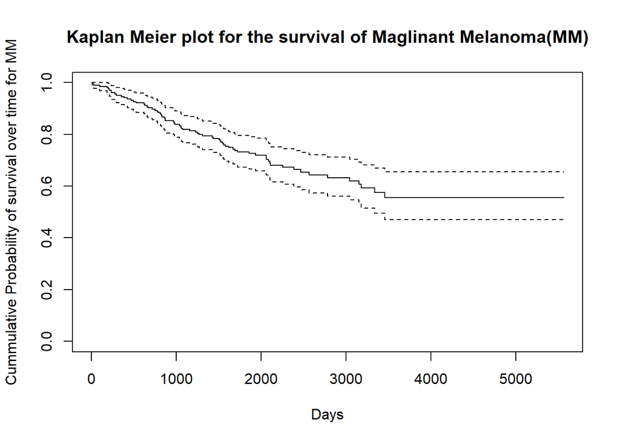

```r
km_fit <- survfit(
  Surv(time, status_general)~1,
  data=melanoma.df
)
plot(km_fit, xlab="Days", ylab="Cummulative Probability of survival over time for MM" ,main = "Kaplan Meier plot for the survival of Maglinant Melanoma(MM)")
```

## KM fit adjusted for gender

[figure not shown]

```r
km_fit_gender <- survfit(
  Surv(time, status_general)~sex,
  data=melanoma.df
)

xlabel = "Days"
ylabel = "Cummulative Probability of survival over time for MM"
plot_title = "Kaplan Meier plot for the survival of Maglinant Melanoma(MM) by gender"
km_gender_plot <- autoplot(km_fit_gender)
km_gender_plot <- km_gender_plot +
  ggtitle(plot_title) +
  labs(x = xlabel, y = ylabel) +
  guides(fill=FALSE) +
  labs(colour = "Gender") +
  scale_color_manual(labels = c("Male", "Female"), values = c(1, 2))
print(km_gender_plot)
```

## KM fit adjusted for Ulceration

[figure not shown]

```r
km_fit_ulcer <- survfit(
  Surv(time, status_general)~ulcer,
  data=melanoma.df
)

plot_title = "Kaplan Meier plot for the survival of Maglinant Melanoma(MM) by ulceration"
km_ulcer_plot <- autoplot(km_fit_ulcer)
km_ulcer_plot <- km_ulcer_plot +
  ggtitle(plot_title) +
  labs(x = xlabel, y = ylabel) +
  guides(fill=FALSE) +
  labs(colour = "Ulceration") +
  scale_color_manual(labels = c("Ulcer Present", "Ulcer Absent"), values = c(1, 2))
print(km_ulcer_plot)
```

## KM fit adjusted for ages 40,50,60,70

“In the U.S., the lifetime risk of developing melanoma was estimated to be about 1 in 28 for Caucasians in the year 2020. The incidence of melanoma is relatively low in dark-skinned populations. Overall, the lifetime risk of developing melanoma is greater for men than women; however, for those under age 50, the inverse is true. The incidence rate begins to rise after puberty, increases until the age of 65 to 70 years, and then decreases with the average age at diagnosis being around 65.”- [Munich Re Life US] [Source](https://www.munichre.com/content/dam/munichre/marc/pdf/malignant-melanoma-may-2020.pdf/_jcr_content/renditions/original./malignant-melanoma-may-2020.pdf)

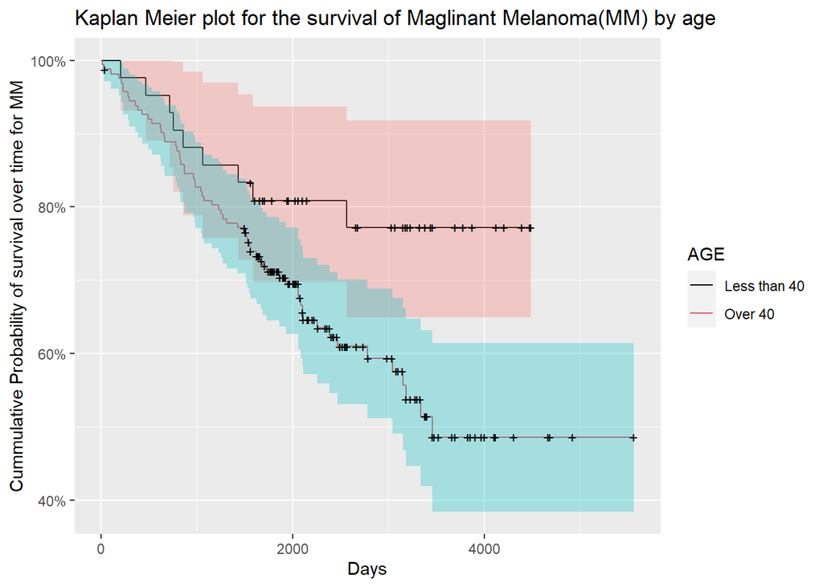

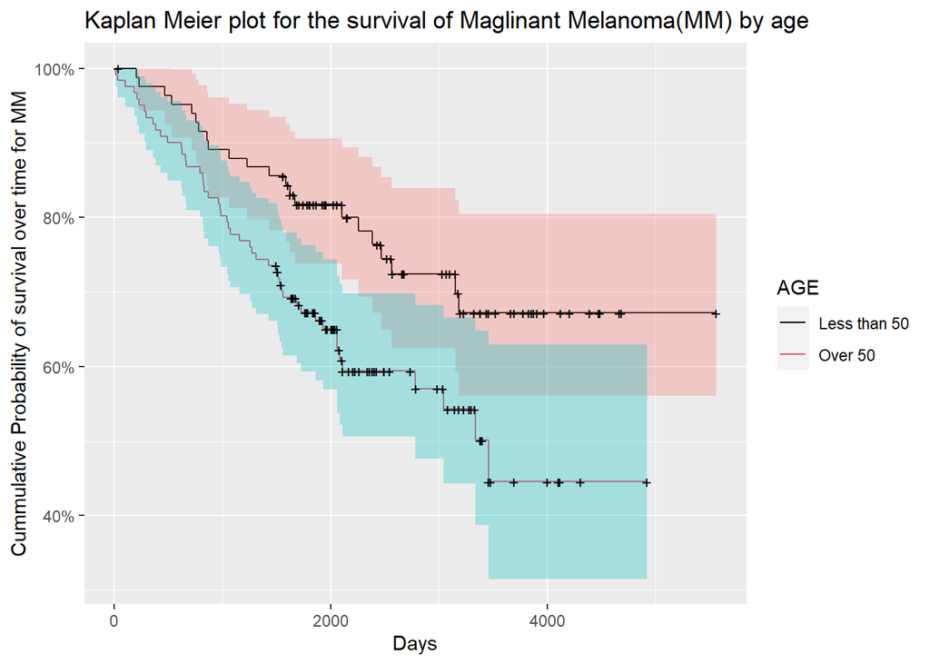

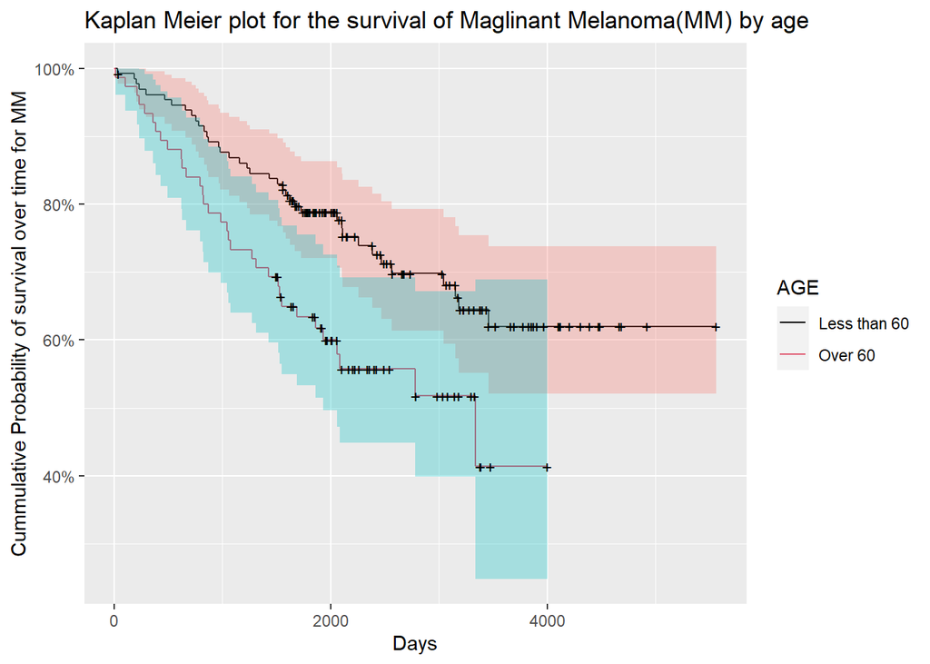

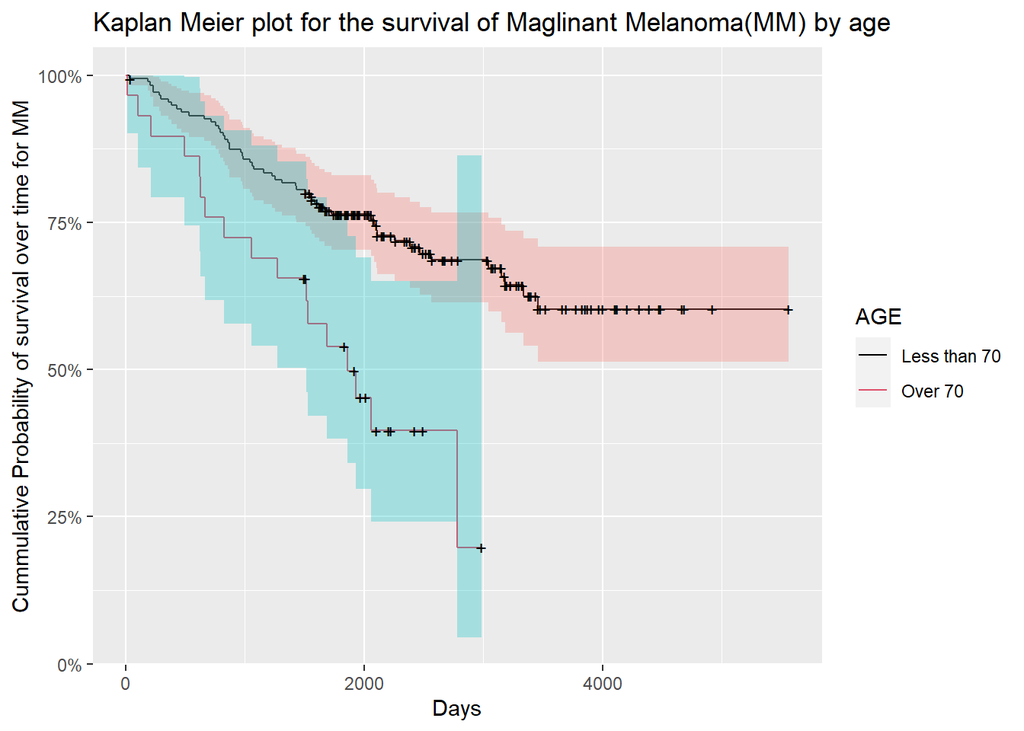

```r
plot_km_age <- function(cutoff_age_arr) {
  for (a in cutoff_age_arr) {
    lt_age = paste("Less than ", a, sep="")
    ov_age = paste("Over ", a, sep="")
    mm_age_adj = melanoma.df %>% mutate(AG = ifelse((age < a), lt_age, ov_age),
                 AG = factor(AG))

    km_fit_age <- survfit(
      Surv(time, status_general)~AG,
      data=mm_age_adj
    )

    plot_title = "Kaplan Meier plot for the survival of Maglinant Melanoma(MM) by age"
    km_age_plot <- autoplot(km_fit_age)
    km_age_plot <- km_age_plot +
      ggtitle(plot_title) +
      labs(x = xlabel, y = ylabel) +
      guides(fill=FALSE) +
      labs(colour = "AGE") +
      scale_color_manual(labels = c(lt_age, ov_age), values = c(1, 2))
    print(km_age_plot)
  }
}

cutoff_ages <- c(40,50,60,70)
plot_km_age(cutoff_ages)
```

## Model fit and variable selection - Cox proportional-hazards model analysis

Testing proportional hazard assumption

```r
par(mfrow=c(2,3))
death_status <-  melanoma.df$status_general
fit.cox = coxph(Surv(time,death_status)~factor(sex)+age+thickness+year+factor(ulcer),method=c("breslow"), na.action=na.exclude, data=melanoma.df)
fit.cox.zph = cox.zph(fit.cox)
summary(fit.cox.zph)
```

```
##           Length Class  Mode
## table      18    -none- numeric
## x          71    -none- numeric
## time       71    -none- numeric
## y         355    -none- numeric
## var        25    -none- numeric
## transform   1    -none- character
## call        2    -none- call
```

```
##               chisq df     p
## factor(sex)   0.503  1 0.478
## age           2.063  1 0.151
## thickness     2.825  1 0.093
## year          0.450  1 0.502
## factor(ulcer) 4.320  1 0.038
## GLOBAL        7.870  5 0.164
```

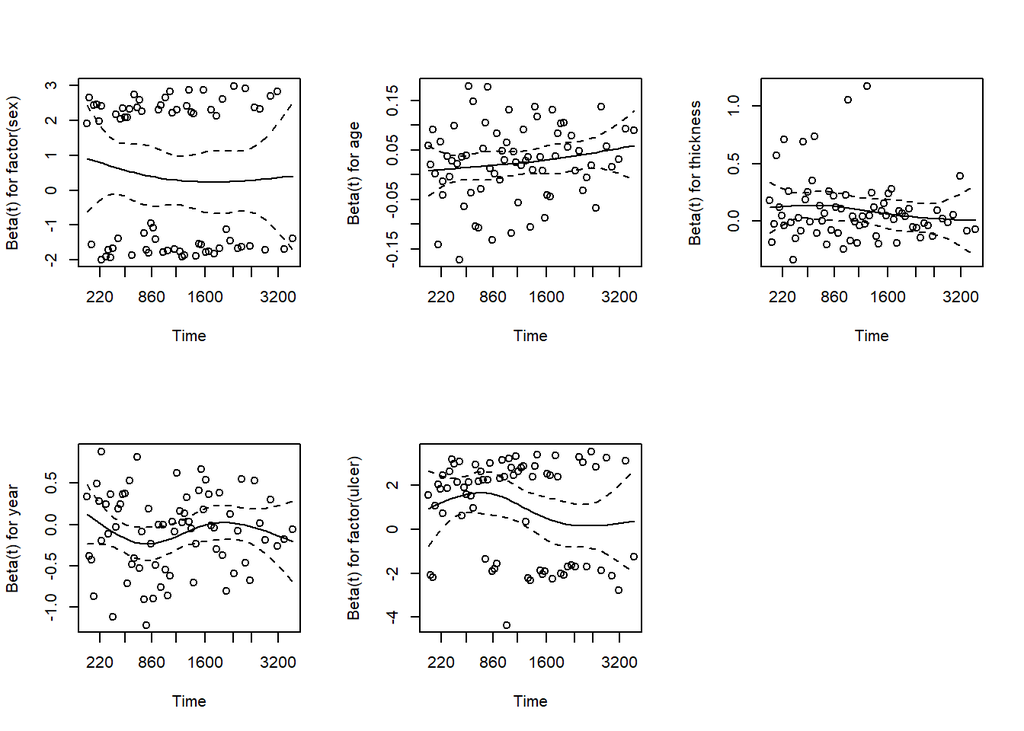

```r
plot(fit.cox.zph)

fit.cox.zph
```

The component `ulcer` with chi-square value of 4.320, under df = 1, has a p-value of 0.038. This implies that Proportional Hazards assumption does not hold. So we need to stratify our ulceration component, and check it again.

```r
par(mfrow=c(2,3))
fit.cox = coxph(Surv(time,death_status)~factor(sex)+age+thickness+year+strata(factor(ulcer)),method=c("breslow"), na.action=na.exclude, data=melanoma.df)
fit.cox.zph = cox.zph(fit.cox)
summary(fit.cox.zph)
```

```
##           Length Class  Mode
## table      15    -none- numeric
## x          71    -none- numeric
## time       71    -none- numeric
## strata     71    factor numeric
## y         284    -none- numeric
## var        16    -none- numeric
## transform   1    -none- character
## call        2    -none- call
```

```
##             chisq df    p
## factor(sex) 0.235  1 0.63
## age         2.144  1 0.14
## thickness   1.406  1 0.24
## year        0.782  1 0.38
## GLOBAL      4.099  4 0.39
```

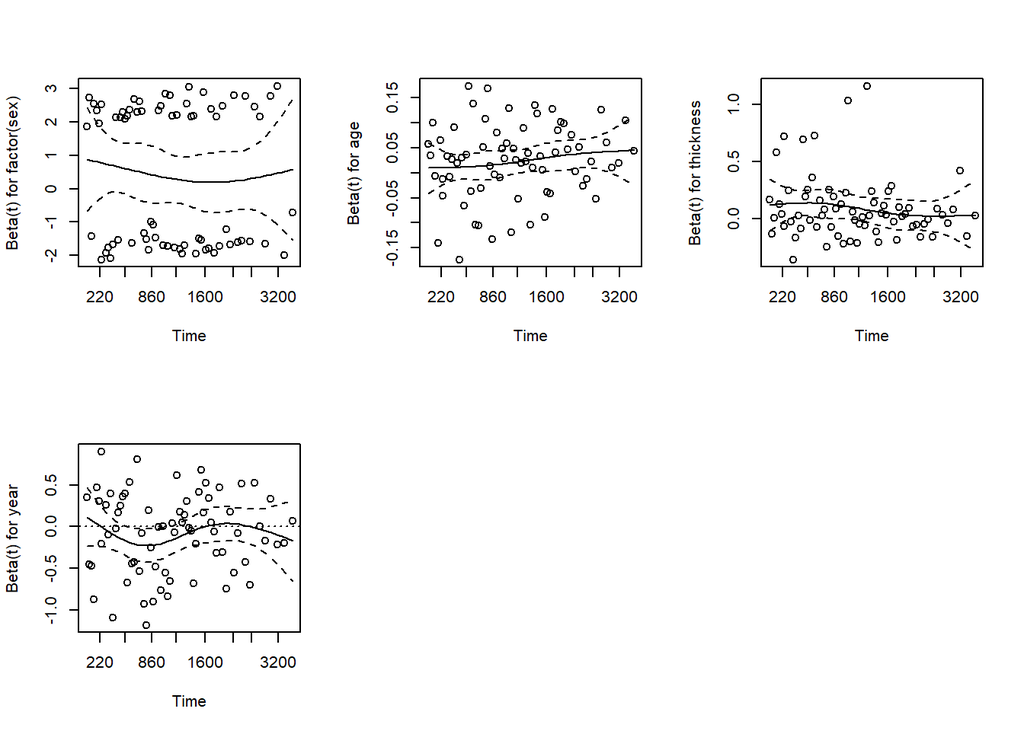

```r
plot(fit.cox.zph)
abline(h=0, lty=3)
fit.cox.zph
```

We perform local tests for each explanatory factor in the model by applying Wald test.

```
## Table 8.6: Local test for possible confounders, adjusted for factors of gender, age, thickness and ulceration
```

```
##     DF, Wald Chi-Squre, p-value, AIC:
```

```
##      [,1]    [,2]      [,3]   [,4]
## [1,]    1 3.63945 0.0564256 579.75
## [2,]    1 7.58297 0.0058922 575.38
## [3,]    1 0.26087 0.6095244 583.11
```

The p_values of sex, and year are more than 0.05. We fail to reject Ho and said sex, and year is not effective. So our finalized model is the one below.

```
## Table 8.9: Analysis of Variance Table for the Final Model for the survival of Malignant Melanoma
```

```
## Call:
## coxph(formula = Surv(time, death_status) ~ strata(factor(ulcer)) +
##     thickness + age, data = melanoma.df, method = c("breslow"))
##
##             coef exp(coef) se(coef)   z     p
## thickness 0.0951    1.0997   0.0334 2.8 0.004
## age       0.0216    1.0219   0.0079 2.8 0.006
##
## Likelihood ratio test=17  on 2 df, p=0.00025
## n= 205, number of events= 71
```

#### Backward AIC method

```r
fit.cox <- coxph(Surv(time,death_status)~1,data=melanoma.df)
stepAIC(fit.cox,  ditrection="backward",trace=-1)
```

```
## Start:  AIC=700.98
## Surv(time, death_status) ~ 1
```

```
## Call:  coxph(formula = Surv(time, death_status) ~ 1, data = melanoma.df)
##
## Null model
##   log likelihood= -350.49
##   n= 205
```

#### Forward AIC method

```r
stepAIC(fit.cox, direction="forward",
        scope=list(lower=fit.cox, upper=~factor(sex)+age+thickness+year+factor(ulcer)))
```

```
## Start:  AIC=700.98
## Surv(time, death_status) ~ 1
##
##                 Df AIC
## + factor(ulcer)  1 676
## + thickness      1 682
## + age            1 689
## + factor(sex)    1 695
## <none>             701
## + year           1 702
##
## Step:  AIC=676.25
## Surv(time, death_status) ~ factor(ulcer)
##
##               Df AIC
## + age          1 667
## + thickness    1 669
## + factor(sex)  1 674
## <none>           676
## + year         1 678
##
## Step:  AIC=667.32
## Surv(time, death_status) ~ factor(ulcer) + age
##
##               Df AIC
## + thickness    1 662
## + factor(sex)  1 666
## + year         1 666
## <none>           667
##
## Step:  AIC=662.04
## Surv(time, death_status) ~ factor(ulcer) + age + thickness
##
##               Df AIC
## + factor(sex)  1 661
## + year         1 662
## <none>           662
##
## Step:  AIC=661.09
## Surv(time, death_status) ~ factor(ulcer) + age + thickness +
##     factor(sex)
##
##        Df AIC
## + year  1 661
## <none>    661
##
## Step:  AIC=660.57
## Surv(time, death_status) ~ factor(ulcer) + age + thickness +
##     factor(sex) + year
```

```
## Call:
## coxph(formula = Surv(time, death_status) ~ factor(ulcer) + age +
##     thickness + factor(sex) + year, data = melanoma.df)
##
##                     coef exp(coef) se(coef)    z     p
## factor(ulcer)Yes  0.9764    2.6549   0.2678  3.6 3e-04
## age               0.0252    1.0255   0.0079  3.2 0.001
## thickness         0.0921    1.0965   0.0349  2.6 0.008
## factor(sex)Male   0.4272    1.5330   0.2396  1.8 0.075
## year             -0.0883    0.9155   0.0551 -1.6 0.109
##
## Likelihood ratio test=50  on 5 df, p=1.1e-09
## n= 205, number of events= 71
```

## Cox proportional-hazards model adjusted for competing risks

#### Cox proportional-hazards model classification 2

We defined this class to be such that the failure time is the MM mortality with 1 as death by MM, 2/3 are alive regardless of other causes of death.

```r
melanoma.df %>%coxphmulti(mm_class, explanatory)
```

```
## Call:
## coxph(formula = as.formula(paste0(dependent, "~", paste(explanatory,
##     collapse = "+"))), data = .data)
##
##             coef exp(coef) se(coef)   z     p
## age       0.0122    1.0123   0.0083 1.5 0.141
## sexMale   0.4328    1.5416   0.2674 1.6 0.106
## thickness 0.1089    1.1151   0.0377 2.9 0.004
## ulcerYes  1.1645    3.2043   0.3098 3.8 2e-04
##
## Likelihood ratio test=42  on 4 df, p=2e-08
## n= 205, number of events= 57
```

#### Cox proportional-hazards model classification 3 - censoring applied

We defined this class to be such that the failure time with censoring adjust for competing risks where 2 represents alive, 1 is death by MM adjusted for 3 which is death by other causes.

```r
melanoma.df%>%crrmulti(cen_class, explanatory)
```

```
## convergence:  TRUE
## coefficients:
##       age   sexMale thickness  ulcerYes
##  0.005928  0.405000  0.089990  1.129000
## standard errors:
## [1] 0.00929 0.27560 0.03836 0.30340
## two-sided p-values:
##       age   sexMale thickness  ulcerYes
##    0.5200    0.1400    0.0190    0.0002
```

# Reference

- Drzewieki K. T., Andersen P., Survival with Malignant Melanoma: A Regression Analysis of Prognostic Factors . American Cancer Society 1988
- [Drzewieki K. T., Andersen P., Malignant Melanoma . Munich American Reassurance Company 2020](https://www.munichre.com/content/dam/munichre/marc/pdf/malignant-melanoma-may-2020.pdf/_jcr_content/renditions/original./malignant-melanoma-may-2020.pdf)